# ALY6040 M3 Technique Practice - SVM

Instructor: Dr. Marcus Ellis

Student: Shahabaddin Feghahati

Completion Date: 03/12/2023

#### Introduction

This code showcases the use of the e1071 package in R for support vector machines (SVM) analysis, a powerful machine learning technique used for classification, regression, and density estimation. It includes loading and fitting models to the iris dataset using different interfaces, evaluating model performance, visualizing results, fitting a regression model, and demonstrating SVM for density estimation. The code provides an introduction to using SVM in R and how to visualize results.

#### Analysis

```r
#install.packages("e1071")

#Loading libraries
library(e1071)
library(rpart,quietly = TRUE)
library(caret,quietly = TRUE)
library(rpart.plot,quietly = TRUE)
library(rattle)
library(readxl)
```

#### *CODE WALK THROUGH*

The code above installs and loads several R packages that will be needed for machine learning and data analysis tasks (Contributed packages, n.d.).

```r
#Reading the data set as a dataframe
data(iris)
attach(iris)
```

#### *CODE WALK THROUGH*

data(iris) loads the iris dataset into memory, while attach(iris) makes the dataset columns available to R’s search path, allowing you to refer to them directly by name without specifying the dataset name.

```r
## classification mode
# default with factor response:
model <- svm(Species ~ ., data = iris)
```

#### *CODE WALK THROUGH*

svm() function is used to build a classification model using support vector machines in R. The Species ~ . specifies the response and predictors in the iris dataset. The resulting model is assigned to model.

```r
# alternatively the traditional interface:
x <- subset(iris, select = -Species)
y <- Species
model <- svm(x, y)

#print(model)
summary(model)
```

```
##
## Call:
## svm.default(x = x, y = y)
##
##
## Parameters:
##    SVM-Type:  C-classification
##  SVM-Kernel:  radial
##        cost:  1
##
## Number of Support Vectors:  51
##
##  ( 8 22 21 )
##
##
## Number of Classes:  3
##
## Levels:
##  setosa versicolor virginica
```

#### *CODE WALK THROUGH*

The result shows the details of the SVM model that was created, including the SVM type, kernel, cost parameter, number of support vectors used, number of classes, and the number of support vectors from each class. It summarizes the model’s configuration and performance (Burger, 2018).

#### *OBSERVATION*

The output provides insights on the SVM model: It uses a radial kernel to consider distance between flowers, assigns equal importance to correctly predict each flower class, and uses a subset of the data to focus on important samples, potentially improving accuracy. These insights can help evaluate the model’s performance in predicting iris flower species based on their characteristics (Burger, 2018).

```r
# test with train data
pred <- predict(model, x)
# (same as:)
pred <- fitted(model)

# Check accuracy:
table(pred, y)
```

```
##             y
## pred         setosa versicolor virginica
##   setosa         50          0         0
##   versicolor      0         48         2
##   virginica       0          2        48
```

#### *CODE WALK THROUGH*

This code evaluates a predictive model’s accuracy by generating predicted values and creating a confusion matrix. The predict and fitted functions are used to generate predicted values, which are then stored in a variable called pred. The table function is used to create a confusion matrix by counting correct and incorrect predictions.

#### *OBSERVATION*

The output shows the confusion matrix, which is a summary of the performance of the classification model. The rows represent the predicted values, and the columns represent the actual values. The model achieved high accuracy and correctly classified all setosa samples, with only 2 misclassifications in versicolor and virginica classes. The SVM model appears to be effective in classifying the dataset, but accuracy may vary depending on hyperparameters and dataset characteristics.

```r
# compute decision values and probabilities:
pred <- predict(model, x, decision.values = TRUE)
attr(pred, "decision.values")[1:4,]
```

```
##   setosa/versicolor setosa/virginica versicolor/virginica
## 1          1.196152         1.091757            0.6708810
## 2          1.064621         1.056185            0.8483518
## 3          1.180842         1.074542            0.6439798
## 4          1.110699         1.053012            0.6782041
```

#### *CODE WALK THROUGH*

The code computes decision values and probabilities for SVM model predictions using the predict function with the decision.values argument set to TRUE. The attr function is used to extract the decision values from the pred object. The purpose is to get insight into the decision-making process of the SVM model.

#### *OBSERVATION*

The output shows the decision values computed by the SVM model for each sample in the Iris dataset. The decision values reflect the distance of each sample from the decision boundary for each pair of classes. We can see that the setosa-versicolor decision values are higher than the setosa-virginica and versicolor-virginica decision values. This indicates that the model is more confident in its classification of the setosa-versicolor class pair than the other two class pairs.

Overall, this information can be useful for understanding the SVM model’s classification process and for further fine-tuning of the model’s performance (Burger, 2018).

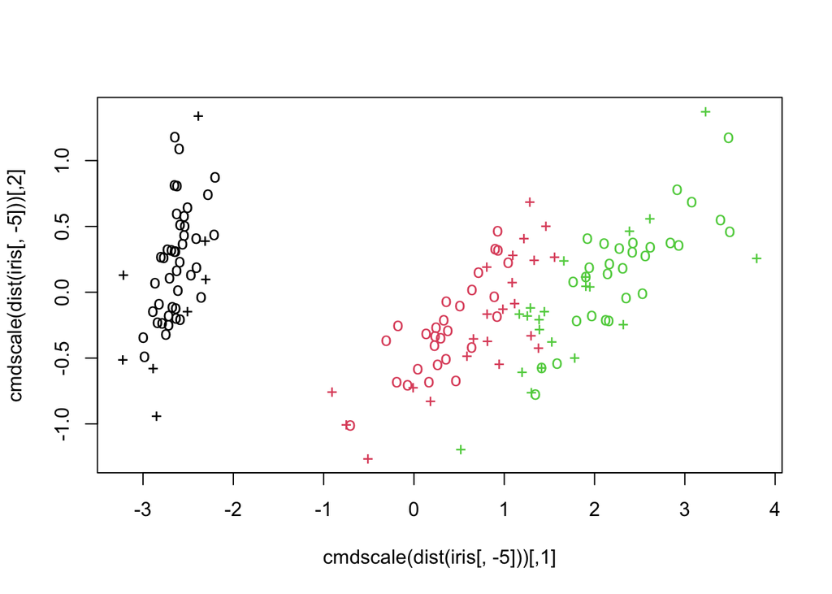

```r
# visualize (classes by color, SV by crosses):
plot(cmdscale(dist(iris[,-5])),
     col = as.integer(iris[,5]),
     pch = c("o","+")[1:150 %in% model$index + 1])
```

#### *CODE WALK THROUGH*

The code generates a scatter plot of the Iris dataset in 2D using multidimensional scaling (MDS) (Cmdscale: Classical (Metric) Multidimensional Scaling, n.d.). Classes are represented by colors, and support vectors are represented by crosses. The cmdscale function performs the MDS on the distance matrix, col represents the class labels, and pch indicates the support vectors. The plot provides insight into the SVM model’s performance on the Iris dataset.

#### *OBSERVATION*

The code generates a scatter plot that shows the SVM model’s separation of Iris dataset samples into different classes, with support vectors marked by crosses. It reveals that the model accurately separates the setosa class but has some difficulty separating versicolor and virginica. This visualization can help identify potential areas for improvement in the model.

```r
## try regression mode on two dimensions

# create data
x <- seq(0.1, 5, by = 0.05)
y <- log(x) + rnorm(x, sd = 0.2)

# estimate model and predict input values
m   <- svm(x, y)
new <- predict(m, x)
```

#### *CODE WALK THROUGH*

The code creates a dataset for regression modeling, fits a support vector machine (SVM) regression model to the data, and generates predictions based on the fitted model using the predict function.

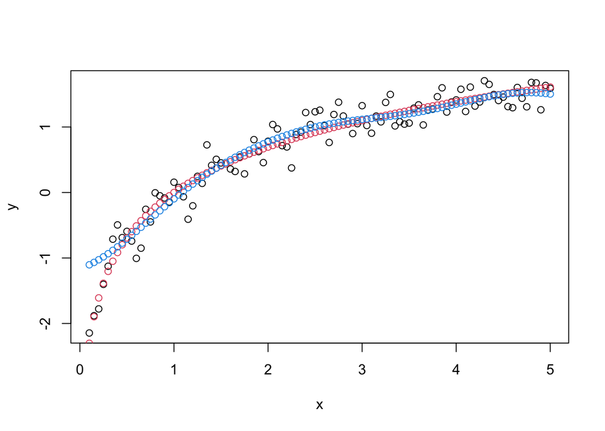

```r
# visualize
plot(x, y)
points(x, log(x), col = 2)
points(x, new, col = 4)
```

#### *CODE WALK THROUGH*

Code creates a scatter plot of x and y using the plot function, then adds logarithm of x points in red and predicted output values from SVM regression model in blue using the points function. This plot shows how well the model fits the data and the relationship between input and output variables.

#### *OBSERVATION*

The scatter plot includes black points representing the synthetic y values, red points representing the true log(x) values, and blue points representing the predicted values from the SVM model. The plot shows that the predicted values follow the same trend as the true log(x) values, with some deviations due to noise and approximations. While the SVM model captures the underlying trend in the data well for many values of x, there are some deviations from the true log(x) values.

```r
## density-estimation

# create 2-dim. normal with rho=0:
X <- data.frame(a = rnorm(1000), b = rnorm(1000))
attach(X)

# traditional way:
m <- svm(X, gamma = 0.1)

# formula interface:
m <- svm(~., data = X, gamma = 0.1)
# or:
m <- svm(~ a + b, gamma = 0.1)

# test:
newdata <- data.frame(a = c(0, 4), b = c(0, 4))
predict (m, newdata)
```

```
##     1     2
##  TRUE FALSE
```

#### *CODE WALK THROUGH*

This code creates a dataset X with two variables, fits an SVM model to it with gamma = 0.1, and makes predictions for new data newdata. Two methods are demonstrated for specifying input data: passing the data frame directly to the function or using the formula interface.

#### *OBSERVATION*

The output of predict is a vector with two elements, indicating the predicted class for each new observation. In this case, the output is TRUE for the first new observation and FALSE for the second new observation.

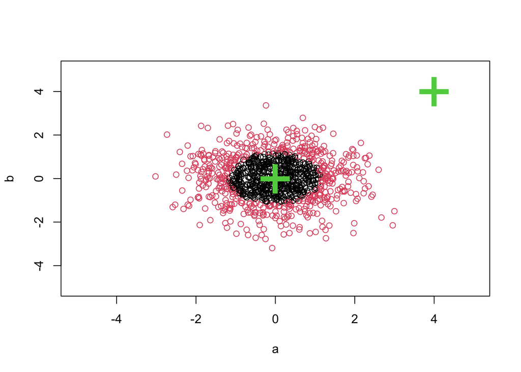

```r
# visualize:
plot(X, col = 1:1000 %in% m$index + 1, xlim = c(-5,5), ylim=c(-5,5))

points(newdata, pch = "+", col = 3, cex = 5)
```

#### *OBSERVATION*

The plot shows the 2-dimensional normal distribution of data points in the dataset X, with each point colored based on whether it is a support vector or not (i.e., part of the margin of the SVM). The two new points are plotted as green crosses.

```r
# weights: (example not particularly sensible)
i2 <- iris
levels(i2$Species)[3] <- "versicolor"
summary(i2$Species)
```

```
##     setosa versicolor
##         50        100
```

```r
wts <- 100 / table(i2$Species)
wts
```

```
##
##     setosa versicolor
##          2          1
```

```r
m <- svm(Species ~ ., data = i2, class.weights = wts)
```

#### *CODE WALK THROUGH*

This code creates a copy of the iris dataset, renames a level of the Species variable, calculates weights for each level, and fits an SVM model with class weights using the updated dataset.

#### *OBSERVATION*

The code output shows the number of observations and class weights for two levels of the Species variable in the iris dataset. The model assigns a higher weight to setosa, which may be due to imbalanced data. This code example is not necessarily practical or relevant in all situations.

#### *RECOMMENDATION FOR ADDITIONAL ANALYSIS*

Recommendations for additional analyses based on the code:

1. Use cross-validation (cross=5) to assess model generalizability and compute accuracy for each fold.
2. Use grid search (tune()) to find the best combination of hyperparameters that maximize accuracy on validation set.
3. Use feature selection (correlation analysis or recursive feature elimination) to identify the most relevant features and evaluate model performance.
4. Compare SVM’s performance with other algorithms (decision trees, random forests, or logistic regression) using the caret package and metrics such as accuracy or AUC.

#### CONCLUSION

In conclusion, the e1071 package in R provides a powerful and flexible implementation of support vector machines (SVMs) for classification, regression, and density estimation tasks. In this report, we walked through some code examples that demonstrate the basic usage of SVMs for classification, regression, and density estimation tasks, including data preparation, model estimation, prediction, and visualization.

We also provided some recommendations for additional analyses, such as cross-validation, grid search, feature selection, and model comparison, to help improve the performance and generalizability of the SVM model.

Overall, SVM is a popular and effective machine learning algorithm that can handle complex data patterns and high-dimensional feature spaces. By leveraging the tools and techniques in the e1071 package, users can easily implement and customize SVM models for a wide range of applications in data science, machine learning, and statistical modeling.

#### REFERENCES

Burger, S. V. (2018). *Introduction to machine learning with R* (1st edition). O’Reilly.

*Contributed packages.* CRAN. (n.d.). Retrieved March 2, 2023, from https://cran.r-project.org/web/packages/

*cmdscale: Classical (Metric) Multidimensional Scaling.* (n.d.). rdocumentation.org. Retrieved March 8, 2023, from https://www.rdocumentation.org/packages/stats/versions/3.6.2/topics/cmdscale

*1.4. Support Vector Machines.* (n.d.). scikit-learn.org. Retrieved March 8, 2023, from https://scikit-learn.org/stable/modules/svm.html

Run R code online. (n.d.). Retrieved March 2, 2023, from https://rdrr.io/snippets/

*svm: Support Vector Machines.* (n.d.). rdocumentation.org. Retrieved March 8, 2023, from https://www.rdocumentation.org/packages/e1071/versions/1.7-13/topics/svm

*Support Vector Machines Part 1 (of 3): Main Ideas!!!* (n.d.). StatQuest. Retrieved March 8, 2023, from https://www.youtube.com/watch?v=efR1C6CvhmE